# A3: SPL Library Checkouts

### Introduction

In this report, I want to analyze the trend of items checked out in the Seattle Public Library from 2017 to 2023. Since library use has been in steady decline across the nation, I want to study the change of types of checked out items from 2017 to 2023. I mainly focus on book, eBook, magazine, audio book, sound disc, videodisc.

### Summary Information

Items with most checkouts in Seattle public library from 2017 to 2023 are *In Building Device Checkout* in 2017, *FlexTech–Laptops* in 2018, *FlexTech–Laptops* in 2019, *So You Want to Talk about Race (Unabridged)* in 2020, *The Vanishing Half: A Novel* in 2021, *The House of Broken Angels* in 2022, *Headphones / Seattle Public Library* in 2023. The number of distinct checkouts from 2017 to 2023 respectively are 36826, 31885, 32262, 25280, 28966, 28922, 12700. The month with most checkouts respectively from 2017 to 2023 are August, January, January, January, August, August, and January. There are 32 material types of checked out items. From 2017 to 2023, eBooks with the most checkouts respectively are *The Girl on the Train: A Novel*, *Crazy Rich Asians: Crazy Rich Asians Series, Book 1*, *After the Flood: A Novel*, *White Fragility: Why It’s So Hard for White People to Talk About Racism*, *The Vanishing Half: A Novel*, *The House of Broken Angels*, *Lessons in Chemistry: A Novel*.

### The Dataset

The data was collected and published by the Seattle Public Library. Parameters of the data were Usageclass, CheckoutType, MaterialType, CheckoutYear, CheckoutMonth, Checkouts, Title, ISBN, Creator, Subjects, Publisher, and Publicationyear. The data might be collected and generated by signing a form or scanning books into a computer system. For the digital items, the media vendors providing usage data were Overdrive, hoopla, Freegal, and RBDigital For the physical items, the source of the data were Legrady artwork data archives and Horizon ILS.The data was collected because it could show a library being well used or not. What’s more, the library could collect this data for planning, developing, and evaluating their services. When working with this data, one ethical question I had was potential bias of this library data. Bias could result in the underrepresentation of certain groups and perspectives in library collection. Certain people can not access to materials in library because of the access restrictions, like membership fee.

One potential limitation of this data was that the data only counted the initial checkout. Renewals of physical items were not counted in this data set. To be specific, if a person borrow a book for a year, the library will only counted the initial checkout. This book would not be counted as a checkout in the next 11 months, but it truly did not in the library. Data in Seattle public library was updated monthly, so the data could be incomplete due to missing information in the following 11 months. Another limitation was related with confidentiality and privacy. Library data may contain confidential and sensitive information about borrowers, including borrowing history and personal information. If the Seattle public library wanted to protect patrons’ privacy, many data would be unavailable and restricted its use for research and analysis. I also noticed that there were 32 material types were recorded, as a result of which the whole dataset would become extremely large and complex. People who were interested in certain topics had to spend time processing this data. Some possible problems with this data were incorrect data entry, data loss, outdated data. Also, due to the different systems across libraries, library data could become inconsistent because of variations in data entry and classifications, which made it hard to analyze and compare data between different libraries.

### First Trends Over Time Chart

I chose to create a stacked bar plot to compare the difference of checkouts between book, eBook, magazine, audio book, sound disc, videodisc in the Seattle public library. We know that the main purpose of the public library is to to provide resources and services in a variety of media to meet the needs of people for information. Therefore, I want to find out what kind of media people use the most to meet needs for education, information, and recreation. The bar plot shows that book, eBook and audio book are the top three types of items with the most checkouts. This bar chart shows that public libraries play an important role in supporting education and literacy.

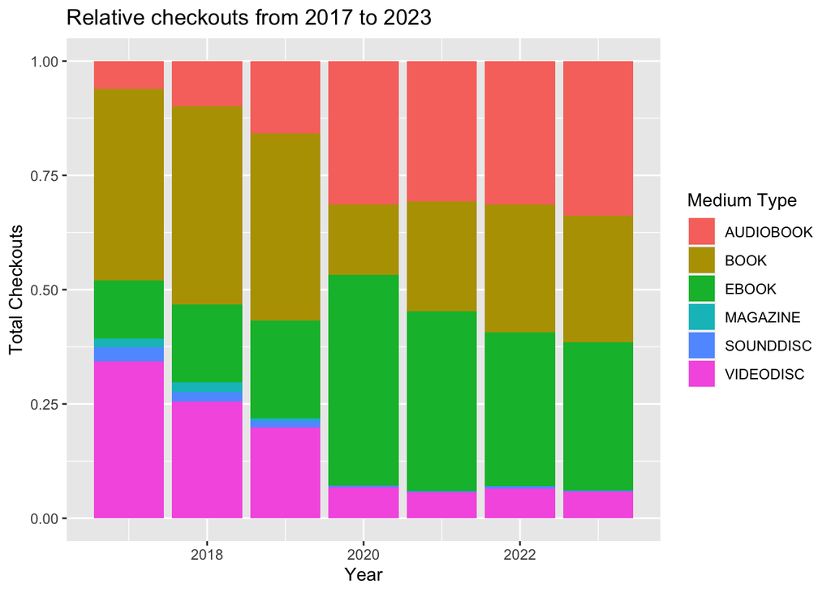

### Second Trends Over Time Chart

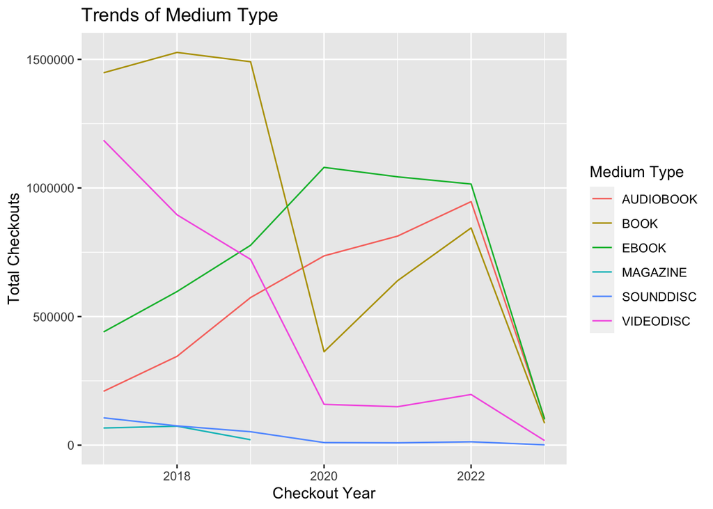

### Your Choice

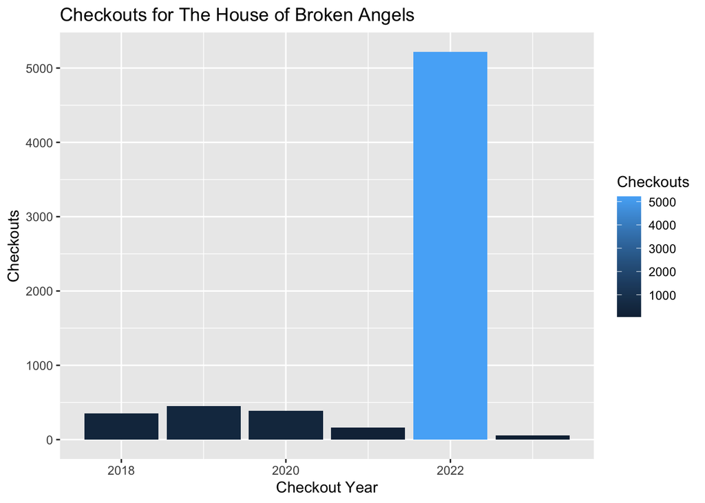